# Regression exercises, MiCM Spring 2023 Workshop

Alex Diaz-Papkovich

03/17/2023

### An exercise in screwing up

This exercise will show you the importance of variable types in R. Say we have three groups of data, labelled 1, 2, and 3. Each of these groups has a different mean. We will try to run a regression on our data and see what the result is.

```r
set.seed(20221011)
# Generate our data
x1 <- rnorm(100, mean = 170, sd = 20)
x2 <- rnorm(100, mean = 140, sd = 20)
x3 <- rnorm(100, mean = 200, sd = 20)
x <- c(x1, x2, x3)

# Generate our labels
labels <- c(rep(1, 100), rep(2, 100), rep(3, 100))

# Create our data frame
screwed_data <- data.frame(x, labels)
colnames(screwed_data) <- c("measurement","group")

# Run our linear regression model
lm_screwed <- lm(measurement ~ group, data = screwed_data)

summary(lm_screwed)
```

```
##
## Call:
## lm(formula = measurement ~ group, data = screwed_data)
##
## Residuals:
##     Min      1Q  Median      3Q     Max
## -70.427 -23.882   3.787  21.107  71.287
##
## Coefficients:
##             Estimate Std. Error t value Pr(>|t|)
## (Intercept)  137.656      4.522  30.441  < 2e-16 ***
## group         16.384      2.093   7.827  8.8e-14 ***
## ---
## Signif. codes:  0 '***' 0.001 '**' 0.01 '*' 0.05 '.' 0.1 ' ' 1
##
## Residual standard error: 29.6 on 298 degrees of freedom
## Multiple R-squared:  0.1705, Adjusted R-squared:  0.1677
## F-statistic: 61.26 on 1 and 298 DF,  p-value: 8.796e-14
```

Our output is this:

```
Coefficients:
            Estimate Std. Error t value Pr(>|t|)
(Intercept)  137.656      4.522  30.441  < 2e-16 ***
group         16.384      2.093   7.827  8.8e-14 ***
---
Signif. codes:  0 ‘***’ 0.001 ‘**’ 0.01 ‘*’ 0.05 ‘.’ 0.1 ‘ ’ 1
```

What’s the problem with the `group` variable? How would you fix it? When you figure it out, you’ll recognize one of the most common mistakes when coding analyses in R.

### Exercises with data

```r
data("PlantGrowth") # Load the data (it may take a second)

#
#plant_anova <- aov(... , data = PlantGrowth)
#plant_regression <- lm(..., data = PlantGrowth)

print("ANOVA results")
```

```
## [1] "ANOVA results"
```

```r
#plant_anova

print("ANOVA summary")
```

```
## [1] "ANOVA summary"
```

```r
#summary(plant_anova)

print("Linear regression results")
```

```
## [1] "Linear regression results"
```

```r
#plant_regression

print("Linear regression summary")
```

```
## [1] "Linear regression summary"
```

```r
#summary(plant_regression)
```

We’re going to look at data from a real study: *Giardiello, Francis M., et al. “Treatment of colonic and rectal adenomas with sulindac in familial adenomatous polyposis.” New England Journal of Medicine 328.18 (1993): 1313-1316.*

The data for this study is in the `medicaldata` library, under `medicaldata::polyps`. The documentation for all data can be found at: https://cran.r-project.org/web/packages/medicaldata/medicaldata.pdf.

Load the data and run a regression on the variable `number12m` against the variable `treatment`. How would you interpret the results?

```r
df_polyps <- medicaldata::polyps

lm_polyps <- lm(number12m ~ treatment, data = medicaldata::polyps)
summary(lm_polyps)
```

```
##
## Call:
## lm(formula = number12m ~ treatment, data = medicaldata::polyps)
##
## Residuals:
##     Min      1Q  Median      3Q     Max
## -28.636  -8.139  -6.389  11.364  27.364
##
## Coefficients:
##                   Estimate Std. Error t value Pr(>|t|)
## (Intercept)         35.636      5.014   7.108 1.27e-06 ***
## treatmentsulindac  -25.747      7.474  -3.445  0.00289 **
## ---
## Signif. codes:  0 '***' 0.001 '**' 0.01 '*' 0.05 '.' 0.1 ' ' 1
##
## Residual standard error: 16.63 on 18 degrees of freedom
##   (2 observations deleted due to missingness)
## Multiple R-squared:  0.3973, Adjusted R-squared:  0.3638
## F-statistic: 11.87 on 1 and 18 DF,  p-value: 0.00289
```

In addition to these variables, you also have a baseline number of polyps for each patient (`baseline`), as well as their age (`age`) and sex (`sex`). Create a regression model that includes these variables as well. How do you interpret these results?

```r
#lm_polyps_multiple <- lm(..., data = medicaldata::polyps)
lm_polyps_multiple <- lm(number12m ~ baseline + treatment + age + sex, data = medicaldata::polyps)

summary(lm_polyps_multiple)
```

```
##
## Call:
## lm(formula = number12m ~ baseline + treatment + age + sex, data = medicaldata::polyps)
##
## Residuals:
##     Min      1Q  Median      3Q     Max
## -20.202 -10.251  -3.595   7.657  23.272
##
## Coefficients:
##                    Estimate Std. Error t value Pr(>|t|)
## (Intercept)        51.83751   13.06029   3.969  0.00123 **
## baseline            0.05931    0.05441   1.090  0.29289
## treatmentsulindac -26.53350    7.10892  -3.732  0.00200 **
## age                -0.70497    0.47822  -1.474  0.16112
## sexmale            -1.37836    8.19318  -0.168  0.86865
## ---
## Signif. codes:  0 '***' 0.001 '**' 0.01 '*' 0.05 '.' 0.1 ' ' 1
##
## Residual standard error: 15.23 on 15 degrees of freedom
##   (2 observations deleted due to missingness)
## Multiple R-squared:  0.579,  Adjusted R-squared:  0.4667
## F-statistic: 5.157 on 4 and 15 DF,  p-value: 0.008127
```

Check the residuals using the `plot` command. Do your residuals look okay?

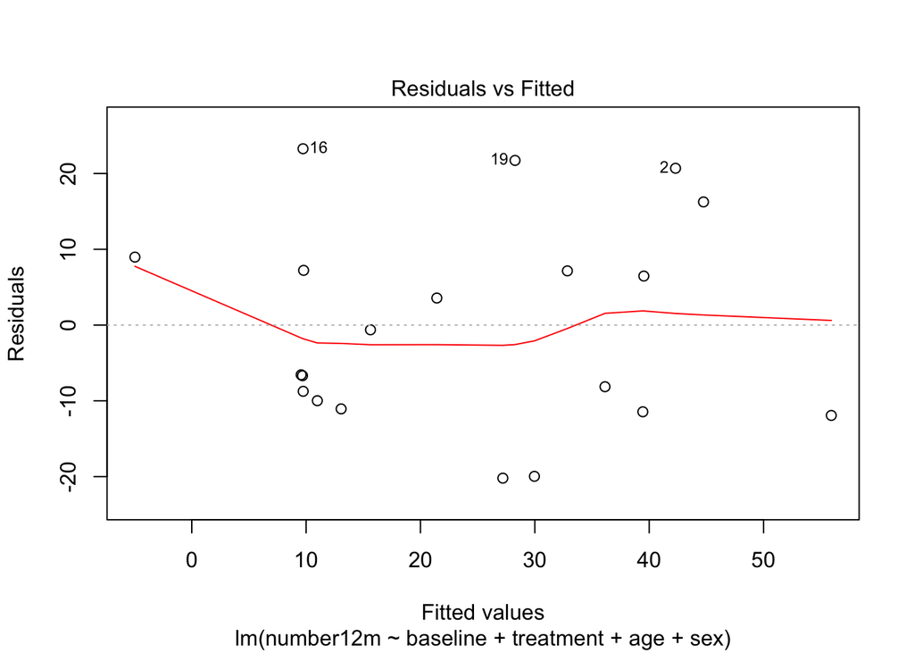

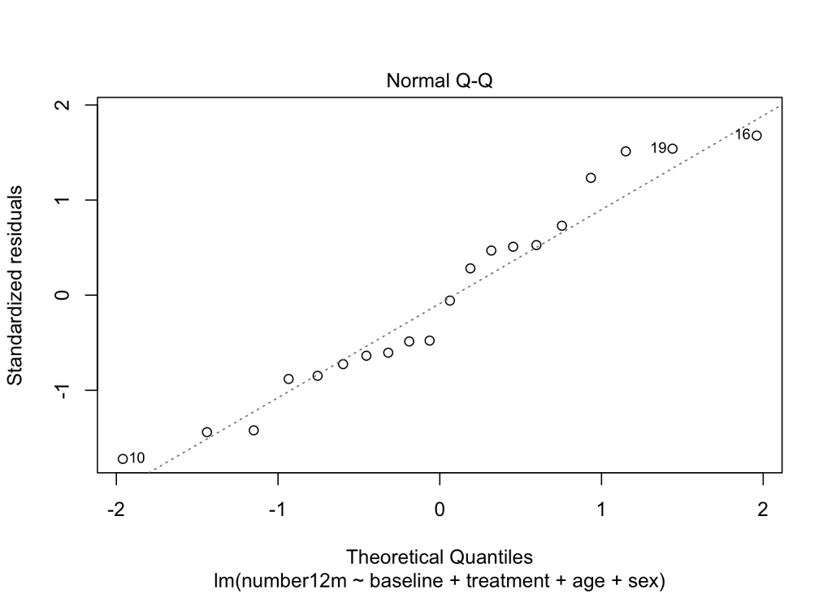

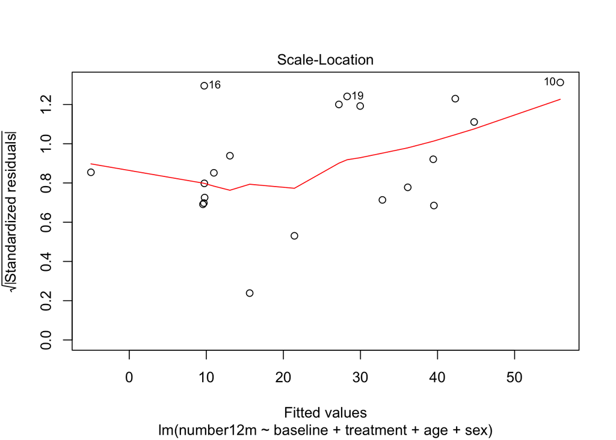

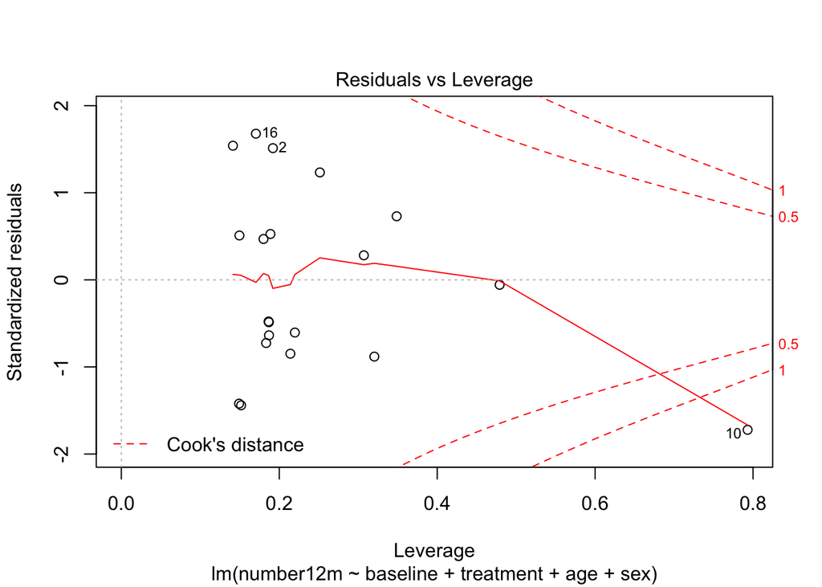

```r
plot(lm_polyps_multiple)
```